## EE 502 P: Analytical Methods for Electrical Engineering

# Homework 5: Differential Equations

## Due 6 November, 2019 at 6:00 PM

### YOUR NAME HERE

Copyright © 2019, University of Washington

**Instructions**: Use this notebook as a template. Answer all questions using well formatted Markdown with embedded LaTeX equations, executable Jupyter cells, or both. Submit your homework solutions as an `.ipynb` file via Canvas.

Although you may discuss the homework with others, you must turn in your own, original work.

**Things to remember:**

- Use complete sentences. Equations should appear in text as grammatical elements.
- Comment your code.
- Label your axes. Title your plots. Use legends where appropriate.
- Before submitting a notebook, choose Kernel -> Restart and Run All to make sure your notebook runs when the cells are evaluated in order.

Note : Late homework will be accepted up to one week after the due date and will be worth 50% of its full credit score.

### 0. Warmup (Do not turn in)

- Make sure you get download, read, and run the notebook for lecture 4. Work through the notebook cell by cell and see what happens when you change the expressions, and make up some of your own.
- The material covered in class is intended to be an introductory subset the general subject of differential equations. To get the full story, an absolutely indispensable book is the one by Hirsch and Smale: https://www.amazon.com/Differential-Equations-Dynamical-Systems-Introduction/dp/0123820103
- The material covered here in particular comes from the beginnings of Chapters 1, 2, 3, 3, 6, 12, and 14.

```python
import scipy.integrate as spi
import numpy as np

import sympy as sm
sm.init_printing(use_latex='mathjax')

import matplotlib.pyplot as plt
import matplotlib.patches as pch
from mpl_toolkits.mplot3d import Axes3D

#This setup will give us great looking plots
import seaborn as sns
sns.set()
'''
colors = ['#1f77b4', '#ff7f0e', '#2ca02c', '#d62728',
          '#9467bd', '#8c564b', '#e377c2', '#7f7f7f',
          '#bcbd22', '#17becf']
sns.set(style='whitegrid', context='notebook', palette=colors,
        rc={'axes.labelsize': 16})
'''
%matplotlib inline
#%config InlineBackend.figure_formats = {'png', 'retina'}
```

```python
# This is just a convenience function for plotting things.
def plot_phase_portrait(matrices,titles):
    """Makes a plot of the phase portraits of the given matrices"""
    fig, ax = plt.subplots(1, len(matrices), figsize=(5*len(matrices)+1,5),squeeze=False)

    x1,x2 = np.meshgrid(np.linspace(-1, 1, 9),np.linspace(-1, 1, 9))

    for i,[matrix,title] in enumerate(zip(matrices,titles)):
        a = np.array(matrix).astype(np.float64)
        x1dot = a[0,0]*x1 + a[0,1]*x2 # x1'(t) = a11 * x1 + a12 * x2
        x2dot = a[1,0]*x1 + a[1,1]*x2  # x2'(t) = a21 * x1 + a22 * x2
        ax[0,i].quiver(x1, x2, x1dot, x2dot, color='r')
        ax[0,i].set_xlabel('$x_1$')
        ax[0,i].set_ylabel('$x_2$')
        ax[0,i].set_title(title)
    return None
```

### 1. Phase Portraits and Linearization (10pts)

For each of the following systems, (i) find the equilibria, (ii) linearize the system around each equilibrium and find the eigenvalues and eigenvectors, (iii) state whether the system is stable at each equilibrium, (iv) draw a phase portrait by first drawing the phase portrait near the equilibria and then interpolating. Compare your drawing to a phase portrait of the entire system generated with Python.

$$ \mathrm{a)} \;\; \begin{pmatrix} \dot x_1 \\ \dot x_2 \end{pmatrix} = \begin{pmatrix} x_2^2 \\ x_1^2 \end{pmatrix} $$$$ \mathrm{b)} \;\; \begin{pmatrix} \dot x_1 \\ \dot x_2 \end{pmatrix} = \begin{pmatrix} x_1^2 + x_2^2 \\ x_2 \end{pmatrix} $$$$ \mathrm{c)} \;\; \begin{pmatrix} \dot x_1 \\ \dot x_2 \end{pmatrix} = \begin{pmatrix} \sin x_2 \\ \cos x_1 \end{pmatrix} $$

$\textbf{Grading breakdown:}$

```
2.5pts for finding the equilibria of (a),(b),(c)
2.5pts for linearizing the system around each equilibrium and finding the eigenvalues and eigenvectors for (a),(b),(c)
2.5pts for stating whether the system is stable at each equilibrium for (a),(b),(c)
2.5pts for generating a phase portrait for (a),(b),(c)
```

1.a)

We consider the system $$ \begin{pmatrix} \dot x_1 \\ \dot x_2 \end{pmatrix} = \begin{pmatrix} x_2^2 \\ x_1^2 \end{pmatrix}. $$

The dynamics have a fixed point (i.e. equilibrium point), $\bar x = \begin{pmatrix} 0 \\ 0 \end{pmatrix}$. So we will linearize about this $\bar x$:

$$ \frac{\partial f}{\partial x} \biggr\rvert_{x = \bar x} = \begin{pmatrix} \frac{\partial (x_2^2)}{\partial x_1} & \frac{\partial (x_2^2)}{\partial x_2} \\ \frac{\partial (x_1^2)}{\partial x_1} & \frac{\partial (x_1^2)}{\partial x_2} \end{pmatrix} = \begin{pmatrix} 0 & 2x_2 \\ 2x_1 & 0 \end{pmatrix} \biggr\rvert_{x = \bar x} = \begin{pmatrix} 0 & 0 \\ 0 & 0 \end{pmatrix} $$

This system has repeated eigenvalues, $\lambda_1 = \lambda_2 = 0$, and linearly independent eigenvectors:

$$v_1 = \begin{pmatrix} 1 \\ 0 \end{pmatrix} \text{, } v_2 = \begin{pmatrix} 0 \\ 1 \end{pmatrix}.$$

Since $\lambda=0$ this system is marginally stable. Here, all solutions are constants. Moreover, since $\frac{\dot x_2}{\dot x_1} = \frac{0}{0}$ the phase portrait is not well defined.

```python
A1 = sm.Matrix([[0,0],[0,0]])
A1.diagonalize()
```

$$\left ( \left[\begin{matrix}1 & 0\\0 & 1\end{matrix}\right], \quad \left[\begin{matrix}0 & 0\\0 & 0\end{matrix}\right]\right )$$

1.b)

We consider the system $$ \begin{pmatrix} \dot x_1 \\ \dot x_2 \end{pmatrix} = \begin{pmatrix} x_1^2 + x_2^2 \\ x_2 \end{pmatrix}. $$

The dynamics have a fixed point, $\bar x = \begin{pmatrix} 0 \\ 0 \end{pmatrix}$. So we will linearize about this $\bar x$:

$$ \frac{\partial f}{\partial x} \biggr\rvert_{x = \bar x} = \begin{pmatrix} \frac{\partial (x_1^2 + x_2^2)}{\partial x_1} & \frac{\partial (x_1^2 + x_2^2)}{\partial x_2} \\ \frac{\partial (x_2)}{\partial x_1} & \frac{\partial (x_2)}{\partial x_2} \end{pmatrix}\biggr\rvert_{x = \bar x} = \begin{pmatrix} 2x_1 & 2x_2 \\ 0 & 1 \end{pmatrix} \biggr\rvert_{x = \bar x} = \begin{pmatrix} 0 & 0 \\ 0 & 1 \end{pmatrix} $$

$$v_1 = \begin{pmatrix} 1 \\ 0 \end{pmatrix} \text{, } v_2 = \begin{pmatrix} 0 \\ 1 \end{pmatrix}.$$

(Note that the axes given by the eigenvectors greatly helps us determine the phase portrait intuitively.)

$$\left ( \left[\begin{matrix}1 & 0\\0 & 1\end{matrix}\right], \quad \left[\begin{matrix}0 & 0\\0 & 1\end{matrix}\right]\right )$$

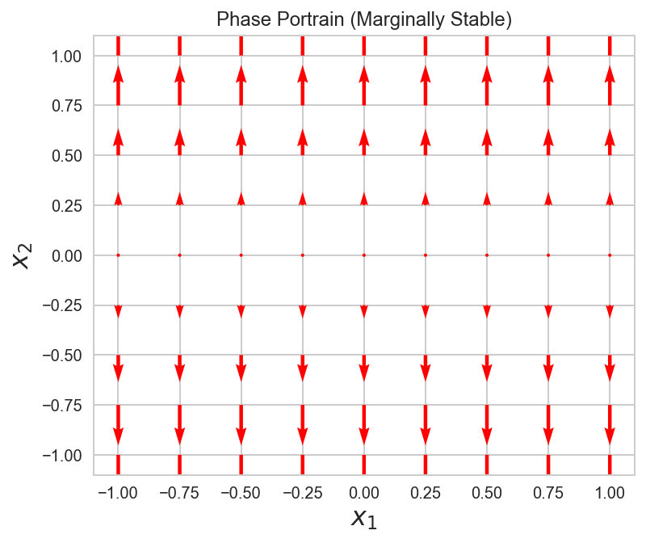

```python
A2 = sm.Matrix([[0,0],[0,1]])
P2, D2 = A2.diagonalize()
plot_phase_portrait([A2],['Phase Portrain (Marginally Stable)'])

P2, D2
```

1.c)

We consider the system:

$$ \begin{pmatrix} \dot x_1 \\ \dot x_2 \end{pmatrix} = \begin{pmatrix} \sin x_2 \\ \cos x_1 \end{pmatrix}. $$

The dynamics have periodic fixed points, $\bar x_n = \begin{pmatrix} \frac{\pi}{2} + n\pi \\ n\pi \end{pmatrix}$ for $n\in\mathbb{Z}$. So we will linearize about this general $\bar x_n$:

$$ \frac{\partial f}{\partial x} \biggr\rvert_{x = \bar x} = \begin{pmatrix} \frac{\partial (\sin{(x_2)})}{\partial x_1} & \frac{\partial (\sin{(x_2)})}{\partial x_2} \\ \frac{\partial (\cos{(x_1)})}{\partial x_1} & \frac{\partial (\cos{(x_1)})}{\partial x_2} \end{pmatrix}\biggr\rvert_{x = \bar x} = \begin{pmatrix} 0 & \cos{(x_2)} \\ -\sin{(x_1)} & 0 \end{pmatrix} \biggr\rvert_{x = \bar x} = \begin{pmatrix} 0 & \cos{(n\pi)} \\ -\sin{(\frac{\pi}{2} + n\pi)} & 0 \end{pmatrix} $$$$\implies A = \pm \begin{pmatrix} 0 & 1 \\ -1 & 0 \end{pmatrix} $$

Case 1 ($n=0$ or is even): It has linearly independent eigenvectors:

$$v_1 = \begin{pmatrix} i \\ 1 \end{pmatrix} \text{, } v_2 = \begin{pmatrix} -i \\ 1 \end{pmatrix}.$$

Case 2 ($n$ is odd): It has linearly independent eigenvectors:

$$v_1 = \begin{pmatrix} -i \\ 1 \end{pmatrix} \text{, } v_2 = \begin{pmatrix} i \\ 1 \end{pmatrix}.$$

$$\left ( \left[\begin{matrix}- i & i\\1 & 1\end{matrix}\right], \quad \left[\begin{matrix}- i & 0\\0 & i\end{matrix}\right], \quad \left[\begin{matrix}i & - i\\1 & 1\end{matrix}\right], \quad \left[\begin{matrix}- i & 0\\0 & i\end{matrix}\right]\right )$$

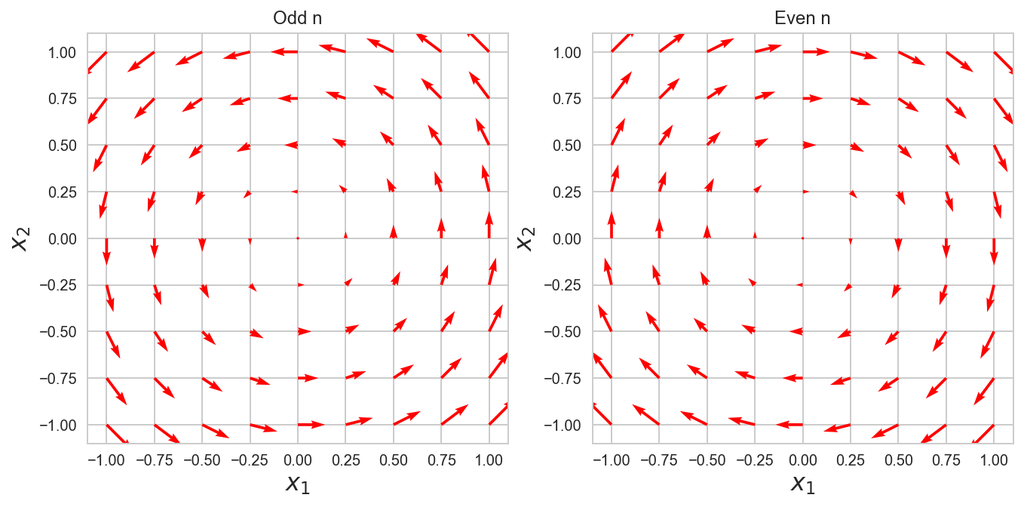

```python
Aeven = sm.Matrix([[0,1],
                   [-1,0]])
Aodd = -Aeven

Podd, Dodd = Aodd.diagonalize()
Peven, Deven = Aeven.diagonalize()
plot_phase_portrait([Aodd, Aeven],['Odd n','Even n'])

Podd,       Dodd,       Peven,       Deven
```

### 2. Nonlinear Systems (10pts)

a) Find a single nonlinear systems that has exactly four distinct equilibria, each of which has a different eigenvalue structure (i.e. a different type in the taxonomy).

b) Find a nonlinear system that has the following phase portrait. Hint: Try polar coordinates. Plot the phase portait in Python.

[figure not shown]

$\textbf{Grading breakdown:}$

```
3pts for finding a nonlinear system that has 4 distinct equilibria
1pt per different eigenvalue structure shown (up to 4pts total)
2pts for finding a nonlinear system that has a limit cycle at r=1, and for r!=1 the trajectories spiral toward r=1
1pt for plotting the phase portrait
```

**Eigenvalue structures**

$\bullet$ Real, distinct: $\begin{cases} \lambda_1,\lambda_2>0 \implies \text{Unstable node}\\ \lambda_1,\lambda_2<0 \implies \text{Stable node}\\ \text{one positive, one negative} \implies \text{Saddle point}\end{cases}$

$\bullet$ Real, repeated: $\begin{cases} \text{two LI eigenvectors} \implies \text{Singular node (could be stable or not)}\\ \text{one LI eigenvector} \implies \text{Degenerate node (could be stable or not)} \end{cases}$

$\bullet$ Real, one zero eigenvalue $\implies$ Marginally stable

$\bullet$ Complex: $\begin{cases} Re(\lambda)<0 \implies \text{Stable focus (i.e. a sprial going toward the center node)} \\ Re(\lambda)>0 \implies \text{Unstable focus (i.e. a sprial going away the center node)} \\ Re(\lambda)=0 \implies \text{Center node in which the trajectories are circles/ellipses} \end{cases}$

2.a)

Consider the system

$$ \begin{pmatrix} \dot x_1 \\ \dot x_2 \end{pmatrix} = \begin{pmatrix} x_1(1-x_1-x_2) \\ 2x_2(1 - \frac{1}{2}x_2 - \frac{3}{2}x) \end{pmatrix}. $$

The dynamics have four fixed points:

$$\bar x_{e1} = \begin{pmatrix} 0 \\ 0 \end{pmatrix},\bar x_{e2} = \begin{pmatrix} 0 \\ 2 \end{pmatrix},\bar x_{e3} = \begin{pmatrix} 1 \\ 0 \end{pmatrix},\bar x_{e4} = \begin{pmatrix} \frac{1}{2} \\ \frac{1}{2} \end{pmatrix}.$$

So we will linearize about each $\bar x_{ei}$:

$$ J = \frac{\partial f}{\partial x} = \begin{pmatrix} \frac{\partial (x_1(1-x_1-x_2))}{\partial x_1} & \frac{\partial (x_1(1-x_1-x_2))}{\partial x_2} \\ \frac{\partial (2x_2(1 - \frac{1}{2}x_2 - \frac{3}{2}x))}{\partial x_1} & \frac{\partial (2x_2(1 - \frac{1}{2}x_2 - \frac{3}{2}x))}{\partial x_2} \end{pmatrix} = \begin{pmatrix} (1-2x_1-x_2) & -x_1 \\ -3x_2 & (2-2x_2-3x_1) \end{pmatrix} $$

At the first fixed point we see,

$$ A_1 = J(0,0) = \begin{pmatrix} 1 & 0 \\ 0 & 2 \end{pmatrix} \implies \begin{cases} \lambda_1 = 1 \\ \lambda_2 = 2 \end{cases}. $$

At the second fixed point we see,

$$ A_2 = J(0,2) = \begin{pmatrix} -1 & 0 \\ -6 & -2 \end{pmatrix} \implies \begin{cases} \lambda_1 = -2 \\ \lambda_2 = -1 \end{cases}. $$

At the third fixed point we see,

$$ A_3 = J(1,0) = \begin{pmatrix} -1 & -1 \\ 0 & -1 \end{pmatrix} \implies \begin{cases} \lambda_1 = -1 \\ \lambda_2 = -1 \end{cases}. $$

At the last fixed point we see,

$$ A_4 = J(\frac{1}{2},\frac{1}{2}) = \begin{pmatrix} \frac{-1}{2} & \frac{-1}{2} \\ \frac{-3}{2} & \frac{-1}{2} \end{pmatrix} \implies \lambda = \frac{-1}{2} \pm \frac{\sqrt{3}}{2} . $$

$$\left ( \left \{ 1 : 1, \quad 2 : 1\right \}, \quad \left \{ -2 : 1, \quad -1 : 1\right \}, \quad \left \{ -1 : 2\right \}, \quad \left \{ - \frac{1}{2} + \frac{\sqrt{3}}{2} : 1, \quad - \frac{\sqrt{3}}{2} - \frac{1}{2} : 1\right \}\right )$$

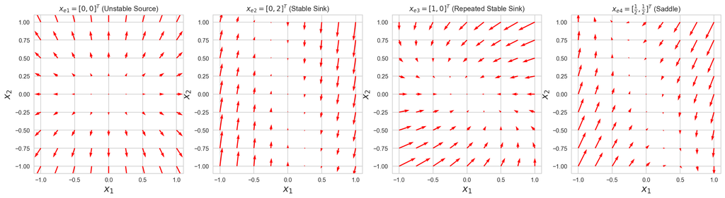

```python
A1 = sm.Matrix([[1,0], # Unstable Source
                [0,2]])

A2 = sm.Matrix([[-1,0], # Stable Sink
                [-6,-2]])

A3 = sm.Matrix([[-1,-1], # Repeated Eigenvalues: Stable Sink
                [0,-1]])

A4 = -sm.Matrix([[sm.Rational(1,2),sm.Rational(1,2)], # Saddle
                 [sm.Rational(3,2),sm.Rational(1,2)]])

plot_phase_portrait([A1, A2, A3, A4],[r'$x_{e1} = [0,0]^T$ (Unstable Source)',
                                      r'$x_{e2} = [0,2]^T$ (Stable Sink)',
                                      r'$x_{e3} = [1,0]^T$ (Repeated Stable Sink)',
                                      r'$x_{e4} = [\frac{1}{2},\frac{1}{2}]^T$ (Saddle)'])

A1.eigenvals(), A2.eigenvals(), A3.eigenvals(), A4.eigenvals()
```

2.b)

**PART 1:**

Consider the highly coupled nonlinear system given by

$$ \begin{pmatrix} \dot x_1 \\ \dot x_2 \end{pmatrix} = \begin{pmatrix} \frac{1}{2}x_1 - x_2 - \frac{1}{2}x_1(x_1^2 + x_2^2) \\ \frac{1}{2}x_2 + x_1 - x_2(x_1^2 + x_2^2) \end{pmatrix} $$

which has a single equilibrium point at $\begin{pmatrix} 0 & 0 \end{pmatrix}^T$.

$$ J = \frac{\partial f}{\partial x} = \begin{pmatrix} \frac{\partial (\frac{1}{2}x_1 - x_2 - \frac{1}{2}x_1(x_1^2 + x_2^2))}{\partial x_1} & \frac{\partial (\frac{1}{2}x_1 - x_2 - \frac{1}{2}x_1(x_1^2 + x_2^2))}{\partial x_2} \\ \frac{\partial (\frac{1}{2}x_2 + x_1 - x_2(x_1^2 + x_2^2))}{\partial x_1} & \frac{\partial (\frac{1}{2}x_2 + x_1 - x_2(x_1^2 + x_2^2))}{\partial x_2} \end{pmatrix} = \begin{pmatrix} (\frac{1}{2} - \frac{3}{2}x_1^2 - x_2^2) & (-1 - 2x_1x_2) \\ (1 - x_1x_2) & (\frac{1}{2} - \frac{3}{2}x_2^2 + x_1^2) \end{pmatrix}. $$

Evaluating the linearized system at the fixed point gives us

$$ A = J(0,0) = \begin{pmatrix} \frac{1}{2} & -1 \\ 1 & \frac{1}{2} \end{pmatrix} \implies \lambda = \frac{1}{2} \pm i $$

which indicates an unstable spiral. But that's not the whole story!

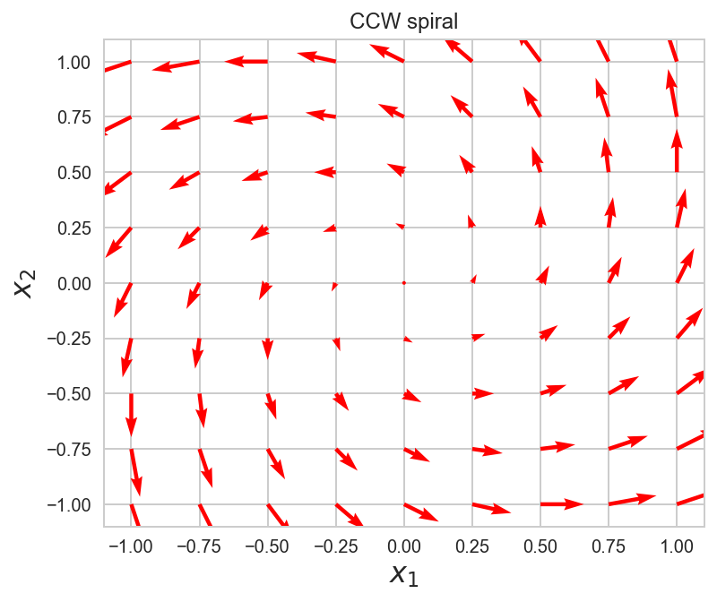

```python
A = sm.Matrix([[sm.Rational(1,2), -1], # unstable CCW spiral
               [1, sm.Rational(1,2)]])
A.eigenvals()

plot_phase_portrait([A],['CCW spiral'])
```

**PART 2:**

Let's introduce polar coordinates. Let $r \geq 0$, $x_1 = r\cos{(\theta)}$, and $x_2 = r\sin{(\theta)}.$ Now let's choose $x_1$ and proceed to take the time derivative. We will equate it with the original dynamics, making the appropriate substitutions:

$$\begin{align} \dot x_1 &= \dot r \cos{(\theta)} - r\sin{(\theta)}\dot \theta \\ &= \frac{1}{2}r\cos{(\theta)} -\frac{1}{2}r^3\cos{(\theta)} - r\sin{(\theta)} \end{align} $$

Now we group the terms by factoring out $\cos{(\theta)}$ to get:

$$\dot r \cos{(\theta)} - r\sin{(\theta)}\dot \theta = \frac{1}{2}(r-r^3)\cos{(\theta)} - r\sin{(\theta)}(1)$$

This implies:

$$\begin{align} \dot r &= \frac{1}{2}r(1-r^2)\\ \dot \theta &= 1 \end{align}$$

The critical points are the origin and $r=1$ which corresponds to the unit circle in the phase plane.

**Conclusions:**

- $\dot \theta =1 \implies$ All nonzero solutions spiral around the origin in the CCW direction.
- $\dot r=\frac{1}{2}r(1-r^2) \implies \dot r = 0$ when $r=0,1$ and solutions on here stay on here.
- $\dot r < 0$ when $r>1 \implies$ solutions outside of the unit circle spiral inward toward it.
- $\dot r > 0$ when $r<1 \implies$ solutions inside of the unit circle spiral outward toward it.

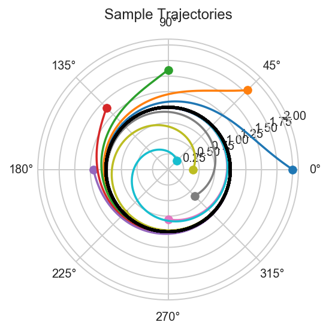

```python
def dynamics(initial, t):
    '''
    Assumes: initial is [r0, theta0] and t is the dummy variable of time instances
    Returns: the dynamics [r_dot, theta_dot]
    '''
    r0,t0 = initial
    r_dot = sm.Rational(1,2)*r0*(1 - r0**2)
    theta_dot = 1
    return [r_dot, theta_dot]

# Set the time instances
t = np.linspace(0., 40, 6000)

# Plot several trajectories
for i in range(10):
    sol = spi.odeint(dynamics,[2-0.2*i, i*sm.pi/4], t); # integrate to get r and theta. Decrement to see the effects of different r
    plt.polar(sol[:,1], sol[:,0]) # Polar line plot
    plt.scatter(sol[0,1],sol[0,0]) # Plot the STARTING points so we can see which direction the curves take

# Plot the limit cycle in bold black
sol = spi.odeint(dynamics,[1,i], t)
plt.polar(sol[:,1], sol[:,0], c='k', lw=2.5)
plt.title('Sample Trajectories')
plt.show()
```

### 3. Tuning Eigenvalues (10pts)

Consider the matrix

$$ A = \begin{pmatrix} k & -k \\ 1 & k-1 \\ \end{pmatrix} $$

and the system $\dot x = A x$. Plot the real part of the eigenvalues of $A$ as a function of $k$, for $k$ ranging from -2 to 2. For what values of $k$ is the system stable? Plot example phase portraits for $A$ when $k$ is in the stable range showing the range of behaviors you can get from tuning $k$.

$\textbf{Grading breakdown:}$

```
4pts for plotting the real part of the eigenvalues as a function of k
3pts for finding the values of k for which the system is stable
3pts for plotting example phase portraits for A in the stable range
```

3.)

Recall that for $A$ to be stable, we require that $\mathrm{Re}(\lambda) < 0$ for all eigenvalues $\lambda$ of $A$. From the graphs we see that for $k \approx 0.55$ or below the system is stable.

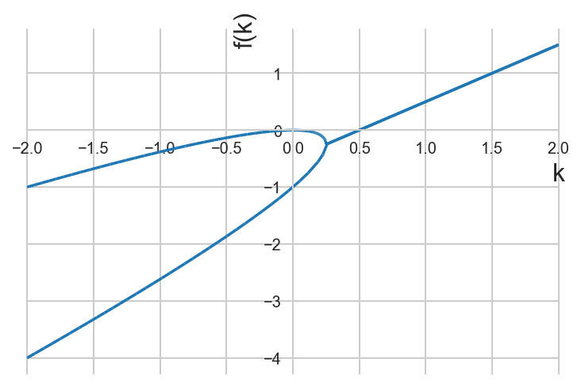

```python
k = sm.symbols('k')

A = sm.Matrix([[k, -k],[1, k-1]])
D = A.diagonalize()[1]

sm.plot(sm.re(D[0,0]), sm.re(D[1,1]), (k,-2,2))
plt.show()
```

```python
'''Alternate solution using numpy'''

# Let's find the threshold where k indicates instability
k = np.linspace(-2, 2, 70) # Our tuning parameter: its value can elicit oscillation behaviors
A = lambda p: sm.Matrix([[p, -p],[1, p-1]]) # Matrix is a function of a tuning parameter

# Extract the real part of the eigenvalues:
# Casting to a list leaves only the eigenvalues but not in a useful data type; casting to complex allows us to us np.real()
reals = [np.real(complex(list(A(k[i]).eigenvals())[j])) for i in range(len(k)) for j in (0,1)]

#Extracts stable eigenvalue pairs representing a particular A(k)
stable_pairs = [reals[i:i+2] for i in range(0, len(reals)-1, 2) if (reals[i:i+2][0] < 0 and reals[i:i+2][1] < 0)]

# find the k that gives the last stable pair in our discretization
k[len(stable_pairs)], len(stable_pairs)
```

$$\left ( 0.5507246376811596, \quad 44\right )$$

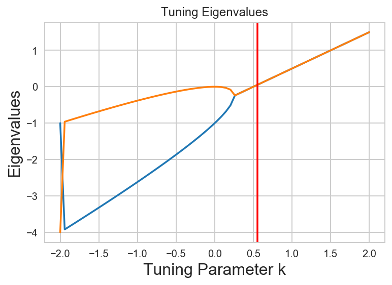

```python
plt.plot(k,reals[::2]) # plot first eigenvalues
plt.plot(k,reals[1::2]) # plot second eigenvalues
plt.axvline(x = k[len(stable_pairs)], c='r')
plt.xlabel('Tuning Parameter k')
plt.ylabel('Eigenvalues')
plt.title('Tuning Eigenvalues')
plt.show()
```

$$\left ( \left[\begin{matrix}-2.0 & 2.0\\1 & -3.0\end{matrix}\right], \quad -2.0\right )$$

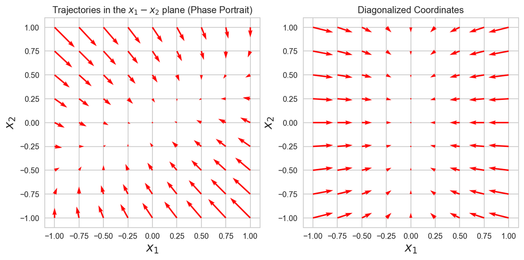

```python
n1 = 0
P,D = A(k[n1]).diagonalize()
plot_phase_portrait([A(k[n1]), D],[r'Trajectories in the $x_1 - x_2$ plane (Phase Portrait)','Diagonalized Coordinates'])
A(k[n1]), k[n1]
```

$$\left ( \left[\begin{matrix}-0.0289855072463767 & 0.0289855072463767\\1 & -1.02898550724638\end{matrix}\right], \quad -0.02898550724637672\right )$$

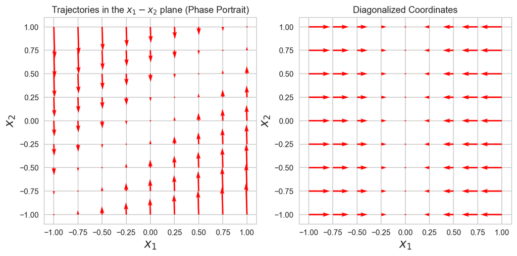

```python
n2 = 34
P,D = A(k[n2]).diagonalize()
plot_phase_portrait([A(k[n2]), D],[r'Trajectories in the $x_1 - x_2$ plane (Phase Portrait)','Diagonalized Coordinates'])
A(k[n2]), k[n2]
```

$$\left ( \left[\begin{matrix}0.260869565217391 & -0.260869565217391\\1 & -0.739130434782609\end{matrix}\right], \quad 0.26086956521739113\right )$$

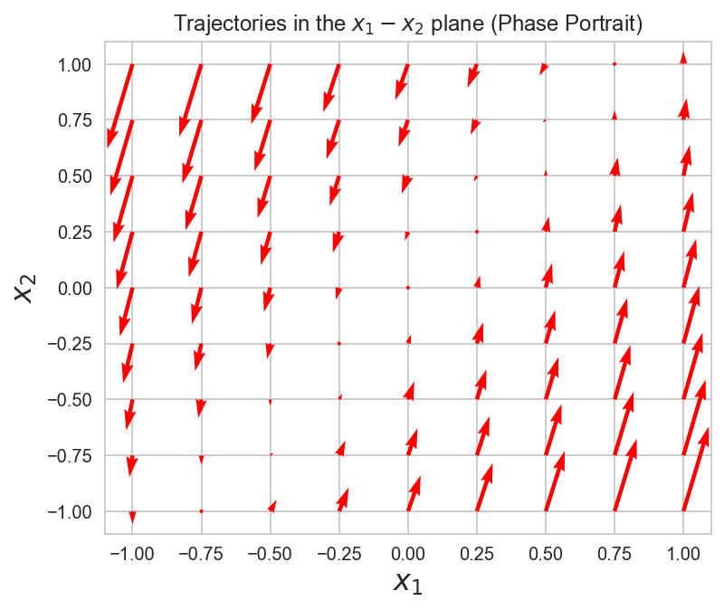

```python
n3 = 39
plot_phase_portrait([A(k[n3])],[r'Trajectories in the $x_1 - x_2$ plane (Phase Portrait)'])
A(k[n3]), k[n3]
```

### 4. Rotations Again (10pts)

Let $\dot x = Ax$

$$ A = \begin{pmatrix} 0 & -w_3 & w_2 \\ w_3 & 0 & -w_1 \\ -w_2 & w_1 & 0 \end{pmatrix} $$

where $w_i \in \mathbb{R}$.

a) Show that $A$ is **skew symmetric**, meaning that, that $A^T = -A$.

b) Show that $e^{At}$ is an **orthonormal** matrix. (Recall that $Q$ is orthonormal if $Q^TQ = QQ^T = I$. Use the definition of the matrix exponential as a series.

c) Show that all points of the form

$$ x = a \begin{pmatrix} w_1 \\ w_2 \\ w_3 \end{pmatrix}, $$

where $a\in \mathbb{R}$, are equilibrum points.

d) Choose a few different choices for the $w_i$ and for each choice show example numerical trajectories by plotting the three components of the state $x$ versus time. Also plot the trajectories in the $x_1$ - $x_2$ plane.

$\textbf{Grading breakdown:}$

```
2pts (a) for showing A^T=-A in sympy or in Latex
1pt (b) for using the definition of the matrix exponential as a series
2pts (b) for showing e^At is orthonormal
2pts (c) for showing x of that form are equilibria in sympy or Latex
1pt (d) for plotting the x,y,z components of the 1st set of numerical trajectories
1pt (d) for plotting the x,y,z components of the 2nd set of numerical trajectories
1pt (d) for plotting the phase portraits
```

```python
#4.a)
w1, w2, w3, t = sm.symbols('w1 w2 w3 t')

A = sm.Matrix([[0, -w3, w2],[w3, 0, -w1],[-w2, w1, 0]])

print('Does A^T = -A? Answer:', str(-A == A.transpose())+',', 'performing the operations and comparing the matrices confirms this.')

A, A.transpose()
```

```
Does A^T = -A? Answer: True, performing the operations and comparing the matrices confirms this.
```

$$\left ( \left[\begin{matrix}0 & - w_{3} & w_{2}\\w_{3} & 0 & - w_{1}\\- w_{2} & w_{1} & 0\end{matrix}\right], \quad \left[\begin{matrix}0 & w_{3} & - w_{2}\\- w_{3} & 0 & w_{1}\\w_{2} & - w_{1} & 0\end{matrix}\right]\right )$$

4.b)

Recall that when $A \in \mathbb{R}^{n\times n}$, then the we define $e^{At}$ by

$$ e^{At} \triangleq I + At + \frac{(At)^2}{2!} + \frac{(At)^3}{3!} + \dots $$

First, we will prove that $(e^{At})^T = e^{A^Tt}$. Beginning with the infinite series definition:

$$ \begin{align} (e^{At})^T &= (\sum \limits_{n=0}^{\infty} (\frac{1}{n!} {(At)^n})^T \text{via definition} \\ &= \sum \limits_{n=0}^{\infty} (\frac{1}{n!} {(At)^n})^T \text{ commutes with addition}\\ &= \sum \limits_{n=0}^{\infty} \frac{1}{n!} ({(At)^n})^T \\ &= \sum \limits_{n=0}^{\infty} \frac{1}{n!} ({(At)^T})^n \text{commutes with powers} \\ &= \sum \limits_{n=0}^{\infty} \frac{1}{n!} ({A^Tt})^n \text{ since t$\in \mathbb{R}$}\\ &= e^{A^Tt}. \end{align}$$

Next, we will check if $[A^T,A]=0$ (i.e. $A^T$ commutes with $A$). If it does, we will leverage our result from HW4 to prove $e^{At}$ is an orthonormal matrix:

$$ [A,B]=0 \implies e^Ae^B = e^{A+B} = e^{B+A} = e^Be^A.$$

```python
LHS = A.transpose() @ A
RHS = A @ A.transpose()
print(LHS == RHS)
LHS, RHS
```

```
True
```

$$\left ( \left[\begin{matrix}w_{2}^{2} + w_{3}^{2} & - w_{1} w_{2} & - w_{1} w_{3}\\- w_{1} w_{2} & w_{1}^{2} + w_{3}^{2} & - w_{2} w_{3}\\- w_{1} w_{3} & - w_{2} w_{3} & w_{1}^{2} + w_{2}^{2}\end{matrix}\right], \quad \left[\begin{matrix}w_{2}^{2} + w_{3}^{2} & - w_{1} w_{2} & - w_{1} w_{3}\\- w_{1} w_{2} & w_{1}^{2} + w_{3}^{2} & - w_{2} w_{3}\\- w_{1} w_{3} & - w_{2} w_{3} & w_{1}^{2} + w_{2}^{2}\end{matrix}\right]\right )$$

Since $[A^T,A]=0$, we can say that

$$e^{A^Tt}e^{At} = e^{(A^T + A)t} = e^{(-A + A)t} = e^O = I.$$

Thus, $e^{A^Tt}$ is an orthonormal matrix.

4.c)

An equilibrium point satisfies $\dot x = f(x) = Ax = 0$. So, if we can show

$$ Ax = A a \begin{pmatrix} w_1 \\ w_2 \\ w_3 \end{pmatrix} = a \begin{pmatrix} 0 & -w_3 & w_2 \\ w_3 & 0 & -w_1 \\ -w_2 & w_1 & 0 \end{pmatrix} \begin{pmatrix} w_1 \\ w_2 \\ w_3 \end{pmatrix} =0 $$

then we can claim $x$ is an equilibrium point of the system for any $a\in\mathbb{R}.$ We verify the calculation in python.

```python
a = sm.symbols('a')
A = sm.Matrix([[0, -w3, w2],[w3, 0, -w1],[-w2, w1, 0]])
xe = a * sm.Matrix([[w1],[w2],[w3]])
A @ xe
```

$$\left[\begin{matrix}0\\0\\0\end{matrix}\right]$$

```python
'''
4.d)

1. Choose a few different choices for the w_i
2. For each choice show example numerical trajectories by plotting the three components of the state x vs time.
3. Also, plot the trajectories in the x_1 - x_2 plane.
'''
w_1, w_2, w_3 = 0, 1, 1
w_12, w_22, w_32 = sm.pi, 0, sm.pi/2

def plotter(A, a, b, c):
    '''
    Assumes A is a matrix; a,b,c are parameters
    Plots the trajectories vs time and returns matrix A evaluated at the parameters
    '''
    A_num = A.subs([(w1, a),(w2, b),(w3, c)])
    P, D = A_num.diagonalize()

    eDt = sm.exp(D*t)
    eAt = P @ eDt @ P.inv()
    x = eAt @ sm.Matrix([1,0,-1]) # e^{At} * (some initial condition)

    sm.plot(x[0], x[1], x[2], (t,0,5));

    return A_num
```

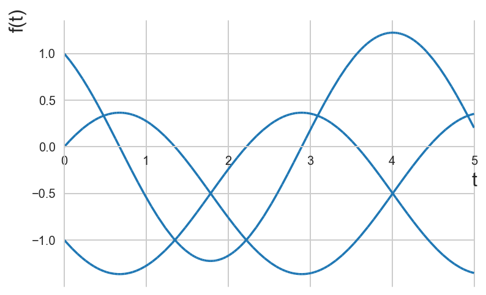

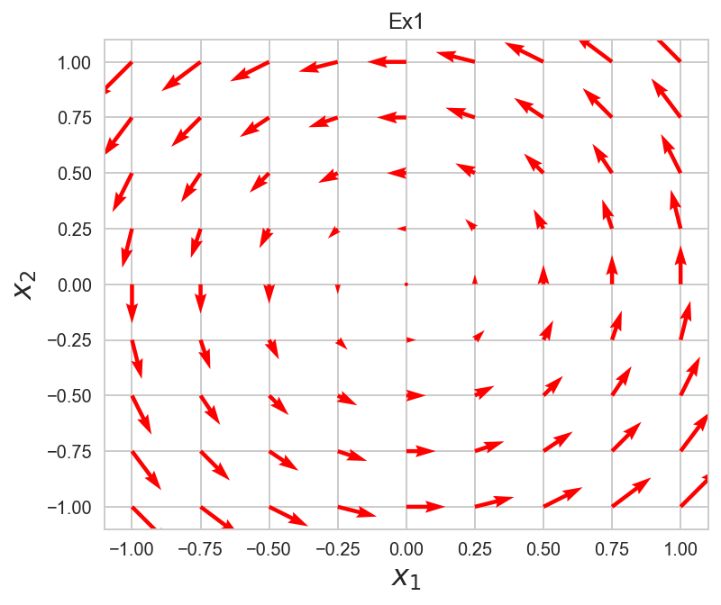

```python
A1 = plotter(A, w_1, w_2, w_3)
plot_phase_portrait([A1],['Ex1'])
```

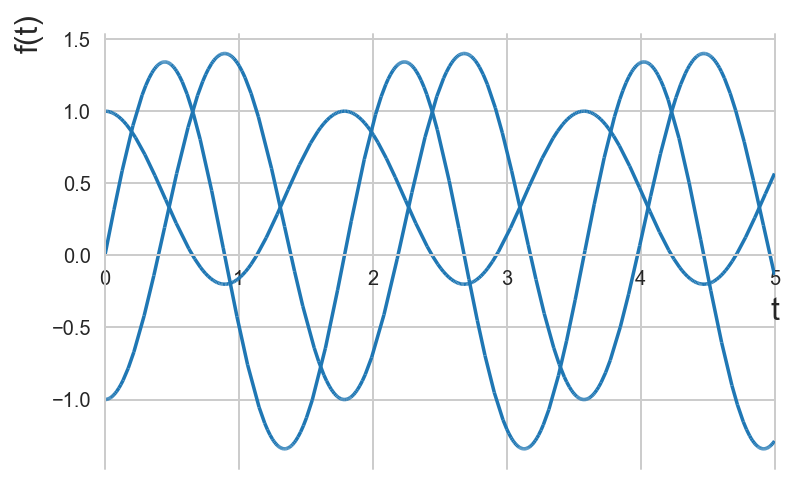

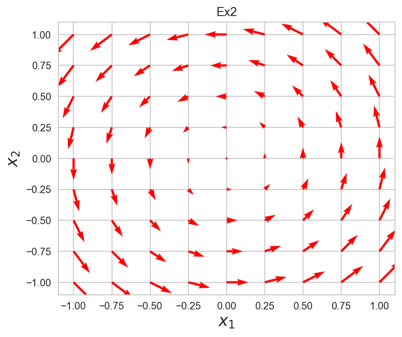

```python
A2 = plotter(A, w_12, w_22, w_32)
plot_phase_portrait([A2],['Ex2'])
```

```python
def rotation_dynamics(X,t,a,b,c):
    '''
    Assumes: X is our initial conditions,
             t is a dummy variable of time for our integrator,
             a,b,c are our values for w1,w2,w3

    Returns: the dynamics xdot, ydot, zdot
    '''
    x,y,z = X
    return [-c*y + b*z,
            -c*x - a*z,
            -b*x + a*y]
```

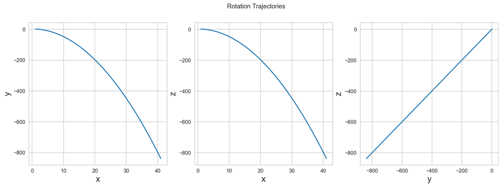

```python
'''
Taking a slice like we did in the Lorentz Attractor example in lecture
'''
t = np.linspace(0., 40, 6000)
X = spi.odeint(rotation_dynamics,[1,2,3],t,args=(w_1,w_2,w_3)); # funtion, initial conditions, variable, other function args

fig,ax = plt.subplots(1,3, figsize=(16,5))
ax[0].plot(X[:,0],X[:,1],label="trajectory 1 xy"); ax[0].set_ylabel('y'); ax[0].set_xlabel('x')
ax[1].plot(X[:,0],X[:,2],label="trajectory 1 xz"); ax[1].set_ylabel('z'); ax[1].set_xlabel('x')
ax[2].plot(X[:,1],X[:,2],label="trajectory 1 yz"); ax[2].set_ylabel('z'); ax[2].set_xlabel('y')
fig.suptitle('Rotation Trajectories')
plt.show()
```

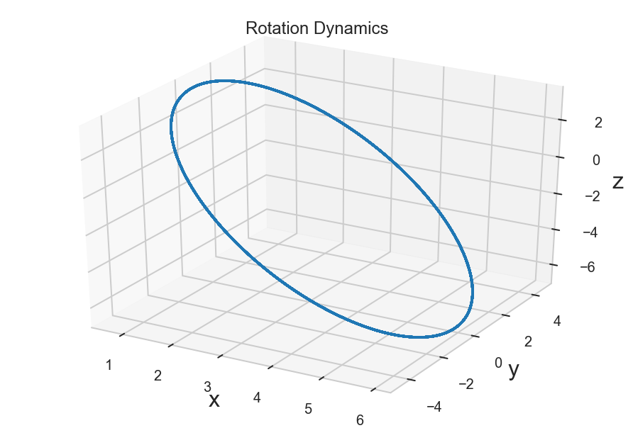

```python
'''
Now let's visualize in 3D using the other set of parameters
'''

fig = plt.figure()
ax = Axes3D(fig) # required for 3D plotting

X2 = spi.odeint(rotation_dynamics,[1,2,3],t,args=(w_12,w_22,w_32)); # funtion, initial conditions, variable, other function args

ax.plot(X2[:,0], X2[:,1], X2[:,2])
ax.set_xlabel('x')
ax.set_ylabel('y')
ax.set_zlabel('z')
ax.set_title('Rotation Dynamics')
plt.show()
```

### 5. Analysis of a Bistable Switch

A genetic bistable switch has the model

$$ \dot u = \frac{\alpha_1}{1 + v^2} - u \\ \dot v = \frac{\alpha_2}{1 + u^2} - v $$

where $\alpha_1$ and $\alpha_2$ are the expression rates of the two proteins $u$ and $v$, and $\beta$ and $\gamma$ are the called Hill coefficients. The behavior of this system is that when one protein is high, the other should be low.

a) Show that when $\alpha_1 = \alpha_2 = \frac{17}{4}$ there are two isolated equilibra corresponding to having one protein be high and the other low. Show that these equilibria are stable. Also show that there number $q$ such that $u=v=q$ is an (un)stable equilibrium. **Note**: You might start this problem by plotting the vector field for this system and finding the equilibria graphically.

b) Find values of $\alpha_1$ and $\alpha_2$ for which there is only equilibrium (assuming positive values for $u$ and $v$). Is this equilibrium stable?

$\textbf{Grading breakdown:}$

```
3pts for finding the equilibria of the system, particularly [0.25,4.0] and [4.0,0.25]
2pts for using the eigenvalues of direction of the phase plot to show that these two equilibria are stable
2pts for finding a q such that q=u=v is not stable, but is a saddle point
2pts (b) for finding values of the alphas for which there is only one equilibrium
1pt (b) for stating the correct stability of this equilibrium
```

5.a)

Let's begin generally with the given dynamics:

$$ \dot u = \frac{\alpha_1}{1 + v^2} - u \\ \dot v = \frac{\alpha_2}{1 + u^2} - v. $$

Linearizing we find

$$ J = \frac{\partial f}{\partial x} = \begin{pmatrix} \frac{\partial (\frac{\alpha_1}{1 + v^2} - u)}{\partial u} & \frac{\partial (\frac{\alpha_1}{1 + v^2} - u)}{\partial v} \\ \frac{\partial (\frac{\alpha_2}{1 + u^2} - v)}{\partial u} & \frac{\partial (\frac{\alpha_2}{1 + u^2} - v)}{\partial v} \end{pmatrix} = \begin{pmatrix} -1 & \frac{-2\alpha_1 v}{(1+v^2)^2} \\ \frac{-2\alpha_2 u}{(1+u^2)^2} & -1 \end{pmatrix} $$

```python
# Initialize variables and constants
u, v = sm.symbols("u v")
a = sm.Rational(17,4)

# Solve the symbolic equations for equilibria
f1 = a / (1+v**2) - u
f2 = a / (1+u**2) - v
sol = sm.solve([f1,f2],(u,v))

# Group the equilibria
fixed_pts = [(sm.simplify(sol[i][0]), sm.simplify(sol[i][1])) for i in range(len(sol))]

# Construct the Jacobian
J = sm.Matrix([[sm.diff(f1,u), sm.diff(f1,v)],
                  [sm.diff(f2,u), sm.diff(f2,v)]])

# Evaluate the Jacobian at each real equilibria
# The last real equilibrium is our q = [1.41526422356121, 1.41526422356121]]
As = []
for i in (0,1,4):
    As.append(J.subs([(u, fixed_pts[i][0]),(v, fixed_pts[i][1])]))

A1, A2, A3 = As

[[sm.N(i[0]),sm.N(i[1])] for i in fixed_pts]
```

$\displaystyle \left[ \left[ 0.25, \ 4.0\right], \ \left[ 4.0, \ 0.25\right], \ \left[ -0.707632111780605 + 1.58184373971301 i, \ -0.707632111780605 + 1.58184373971301 i\right], \ \left[ -0.707632111780605 - 1.58184373971301 i, \ -0.707632111780605 - 1.58184373971301 i\right], \ \left[ 1.41526422356121, \ 1.41526422356121\right]\right]$

$$\left \{ - \frac{25}{17} : 1, \quad - \frac{9}{17} : 1\right \}$$

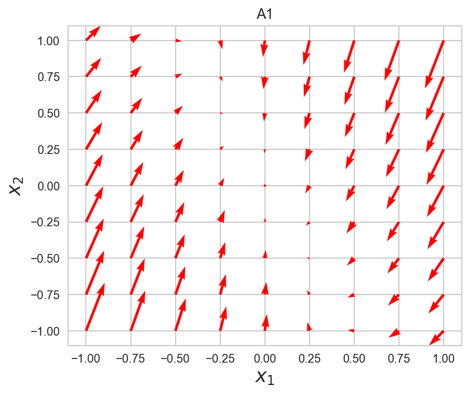

```python
plot_phase_portrait([A1],['A1'])
A1.eigenvals() #Both negative => stable
```

$$\left \{ - \frac{25}{17} : 1, \quad - \frac{9}{17} : 1\right \}$$

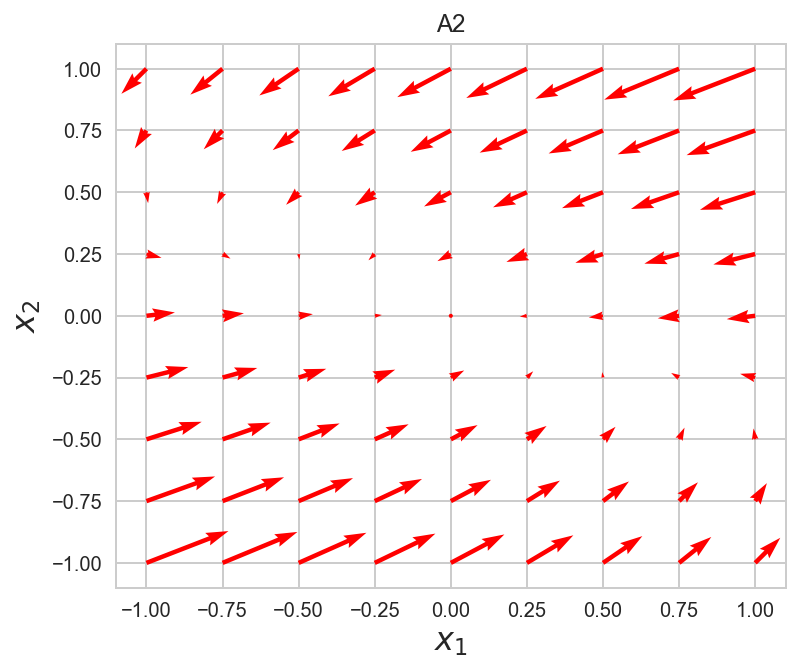

```python
plot_phase_portrait([A2],['A2'])
A2.eigenvals() #Both negative => stable
```

$$\left [ -2.33399330655943, \quad 0.333993306559431\right ]$$

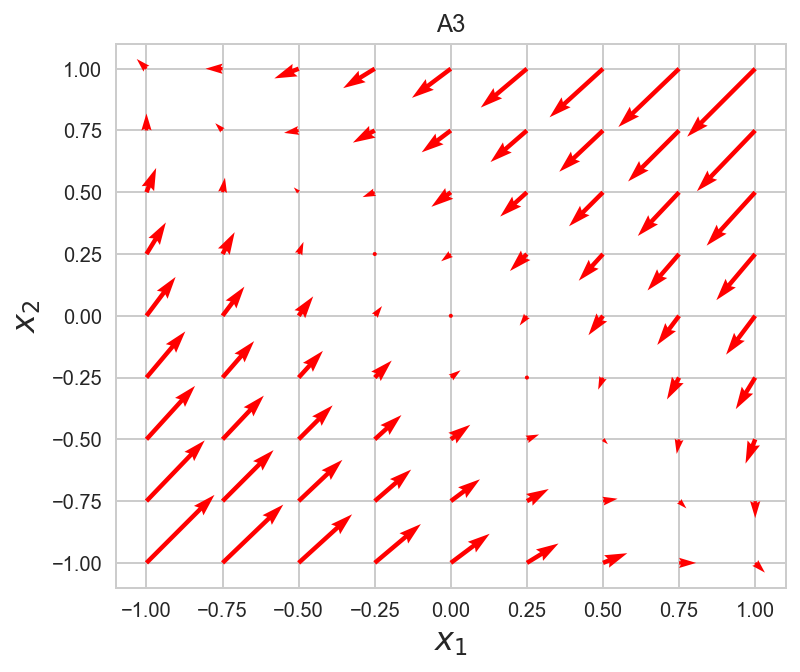

```python
plot_phase_portrait([A3],['A3'])
[sm.N(i) for i in list(A3.eigenvals().keys())] # 1 pos, 1 neg => Saddle point
```

5.b)

When $\alpha_1 = \alpha_2 = \alpha = u(1 + v^2)$ or $v(1 + u^2)$, then the only possilble equilibrium is $\bar x = \begin{pmatrix} 1 & 1\end{pmatrix}^T$. And in either case (the second is shown below)

$$ J(1,1)= \begin{pmatrix} \frac{2uv}{1+v^2} - 1 & \frac{-2v^2(1 + u^2)}{(1+v^2)^2} + \frac{1+u^2}{1+v^2} \\ 0 & 0 \end{pmatrix}\bigg \rvert_{\bar x} = \begin{pmatrix} 0 & 0 \\ 0 & 0 \end{pmatrix}.$$

The eigenvalues of $J(1,1)$ are $\lambda = 0,0$. Thus, this equilibrium is marginally stable.

```python
# Check our Jacobian
a = v*(1 + u**2)
f1 = a / (1 + v**2) - u
f2 = a / (1 + u**2) - v
# Construct the Jacobian
J = sm.Matrix([[sm.diff(f1,u), sm.diff(f1,v)],
               [sm.diff(f2,u), sm.diff(f2,v)]])
J
```

$\displaystyle \left[\begin{matrix}\frac{2 u v}{v^{2} + 1} - 1 & - \frac{2 v^{2} \left(u^{2} + 1\right)}{\left(v^{2} + 1\right)^{2}} + \frac{u^{2} + 1}{v^{2} + 1}\\0 & 0\end{matrix}\right]$

```python
A = sm.Matrix([[0,0],[0,0]])
#plot_phase_portrait([A],[r'$\alpha_1=\alpha_2$']) Can't plot Phase portrait for this one
A.eigenvals() # one 0 eigenvalue => marginally stable
```

$\displaystyle \left\{ 0 : 2\right\}$

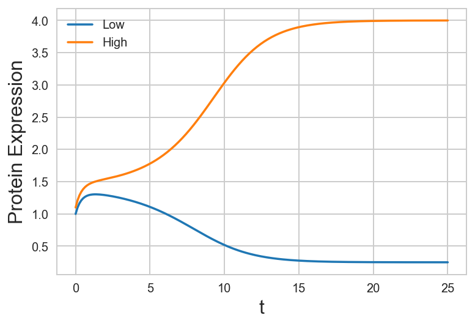

```python
# Graphically, the switch behaves like so

def switch(init,t):
    '''
    Assumes init are the values u0,v0 and t is a dummy variable for the integrator
    Returns a list of the Bistable switch's dynamics
    '''
    u,v = init
    a = sm.Rational(17,4)
    return [a / (1 + v**2) - u,
            a / (1 + u**2) - v]
# Initial condition
init = [1, 1.1]

# Solve
t = np.linspace(0, 25, 200)
uv = spi.odeint(switch, init, t)
plt.plot(t, uv)
plt.xlabel('t')
plt.ylabel('Protein Expression')
plt.legend(('Low', 'High'));
```

### 6. Simulation

Using simulation and visualization, explain the behavior of the system

\begin{eqnarray} \dot x & = & -y - z \\ \dot y & = & x + a y \\ \dot z & = & b + z(x-c) \end{eqnarray}

where $a=0.2$, $b=0.2$ and $c=5.7$.

$\textbf{Grading breakdown:}$

```
3pts for defining the dynamics of the system
2pts for integrating the dynamics via odeint, an euler scheme, or some other scheme
2pts for providing a 3D plot or 2D slices
3pts for explaining the behavior of the system
```

6.)

This system is called the Rossler Chaotic Attractor, and its chaotic behavior is sensitive to initial conditions. We will use python to visualize the changes in behavior after slightly perturbing the inital conditions.

With these parameters it has two complex eigenvalues that make the attractor spiral outward in the xy plane. The last negative eigenvalue is responsible for the motion that occurs within the attractor on the z axis.

```python
def Rossler(x, y, z, a, b, c):
    '''
    Assumes: x, y, z are spacial variables and a, b, c are constants
    Returns: the Rossler Chaotic attractor dynamics xdot, ydot, zdot
    '''
    xdot = -y - z
    ydot = x + a*y
    zdot = b + z*(x - c)
    return xdot, ydot, zdot

def integrate_Rossler(x, y, z, a, b, c, n):
    '''
    Assumes: x, y, z are (n+1,) sized, initialized arrays and a, b, c are constants
    Returns: the solution to the Rossler dynamics x, y, z via Euler scheme
    '''
    for i in range(n):
        xdot, ydot, zdot = Rossler(x[i], y[i], z[i], a=a, b=b, c=c)
        x[i+1] = x[i] + xdot*dt
        y[i+1] = y[i] + ydot*dt
        z[i+1] = z[i] + zdot*dt
    return x, y, z
```

```python
# Initialize variables
a = 0.2
b = 0.2
c = 5.7
dt = 0.01
MAX = 6000

# Preallocate appropriately sized arrays
xs, xs2 = np.empty((MAX+1, )), np.empty((MAX+1, ))
ys, ys2 = np.empty((MAX+1, )), np.empty((MAX+1, ))
zs, zs2 = np.empty((MAX+1, )), np.empty((MAX+1, ))

# Initialize x, y, z
xs[0], ys[0], zs[0] = 1.0, 1.0, 1.0 # 1st data set

xs2[0], ys2[0], zs2[0] = 1.0, 1.1, 1.0 # 2nd data set

# Here we use iteration to solve the ODEs
xs, ys, zs = integrate_Rossler(xs, ys, zs, a, b, c, MAX)
xs2, ys2, zs2 = integrate_Rossler(xs2, ys2, zs2, a, b, c, MAX)
```

[figure not shown]

```python
fig = plt.figure()
ax = Axes3D(fig) # required for 3D plotting

ax.plot(xs, ys, zs, lw=0.5, c='purple')
ax.plot(xs2, ys2, zs2, lw=0.5, c='c')
ax.set_xlabel('x')
ax.set_ylabel('y')
ax.set_zlabel('z')
ax.set_title('Dynamics of the Rossler Attractor')
ax.legend([r'$x_0=1,y_0=1.1,z_0=1$', r'$x_0=1,y_0=1,z_0=1$'], loc='center left')
plt.show()
```